[figure not shown]

EN(STI)(diag)-19

Engine Control Module (ECM) I/O Signal

ENGINE (DIAGNOSTICS)

5. Engine Control Module (ECM) I/O Signal

A: ELECTRICAL SPECIFICATION

Description

Connector

No.

Te rmi -

nal

No.

Signal (V)

Note

Ignition SW ON

(engine OFF)

Engine ON

(idling)

Crankshaft

position sen-

sor

Signal (+) B137 17 0 –7 — +7 Waveform

Signal (–) B137 25 0 0 —

Shield B137 31 0 0 —

Front oxygen

(A/F) sensor

Signal (+) B136 19 2.8 — 3.2 2.8 — 3.2 —

Signal (–) B136 18 2.4 — 2.7 2.4 — 2.7 —

Rear oxygen

sensor

Signal B136 20 0 0 — 0.9 —

Oxygen sen-

sor

Shield B136 9 0 0 —

Front oxygen

(A/F) sensor

heater

Signal 1 B136 6 — — Waveform

Signal 2 B136 5 — — Waveform

Rear oxygen sensor heater

signal

B135 6 0 — 13 12 — 14 Waveform

Engine cool-

ant tempera-

ture sensor

Signal B137 22 1.0 — 1.4 1.0 — 1.4 After engine is warmed up.

Air flow sensor

Signal B136 22 — 0.3 — 4.5 —

Shield B136 10 0 0 —

Ground B136 11 0 0 —

Intake air temperature sen-

sor signal

B136 31 0.3 — 4.6 0.3 — 4.6 —

Wastegate control solenoid

valve

B134 33 0 or 10 — 13 0 or 12 — 14 Waveform

Starter switch B136 16 0 0

Model without push button

start

Cranking: 8 — 14

Model with push button

start

Cranking: waveform

EN-05288

B134

567

8

21

9

43

10

1112131415

2627

28

1617

18192021

3334 29

32 3031

B136

56

78

21

9

43

10

111213

14

15

2627

28

16

1718192021

3334

29

32

30

3135

B135

567

8

21

9

43

10

24 222325

1112131415

2627

28

16171819

2021

B137

567

8

21

9

43

10

2223

1112131415

2425

26

1617

18192021

[figure not shown]

EN(STI)(diag)-20

Engine Control Module (ECM) I/O Signal

ENGINE (DIAGNOSTICS)

Accessory cut request B135 32 10 — 13 12 — 14

Model with push button

start

Cranking: 0

Starter switch 2 B136 27 0 0

Model with push button

start

Cranking: 8 — 14

Starter cut relay B135 34 0 0

Model with push button

start

Cranking: 8 — 14

Ignition switch B136 30 10 — 13 12 — 14 —

Neutral position switch B136 35

ON: 0

OFF: 10 — 13

ON: 0

OFF: 12 — 14

—

Delivery mode switch B136 34 10 — 13 13 — 14 When connected: 0

Knock sensor

Signal B137 2 2.45 — 2.55 2.45 — 2.55 —

Shield B137 8 0 0 —

Back-up power supply B136 2 10 — 13 12 — 14

Ignition switch “OFF”:

10 — 13

Control module power sup-

ply

B136 1 10 — 13 12 — 14 —

B137 7 10 — 13 12 — 14 —

Sensor power supply

B134 19 5 5 —

B135 22 5 5 —

Ignition control

#1 B134 21 0 0 or 5 Waveform

#2 B134 22 0 0 or 5 Waveform

#3 B134 31 0 0 or 5 Waveform

#4 B134 32 0 0 or 5 Waveform

Fuel injector

#1 B134 10 10 — 13 1 — 14 Waveform

#2 B134 11 10 — 13 1 — 14 Waveform

#3 B134 12 10 — 13 1 — 14 Waveform

#4 B134 13 10 — 13 1 — 14 Waveform

Fuel pump

control unit

Control B136 33 0 or 5 0 or 5 Waveform

Diagnostic

signal

B135 10 10 — 13 12 — 14 —

A/C relay control B135 35

ON: 0.5 or less

OFF: 10 — 13

ON: 0.5 or less

OFF: 12 — 14

—

Main fan relay control B135 12

ON: 0.5 or less

OFF: 10 — 13

ON: 0.5 or less

OFF: 12 — 14

—

Sub fan relay control B135 11

ON: 0.5 or less

OFF: 10 — 13

ON: 0.5 or less

OFF: 12 — 14

—

Engine speed output B135 15 — 0 — 13 or more

Model with push button

start

Waveform

Purge control solenoid valve

1

B137 6

ON: 1 or less

OFF: 10 — 13

ON: 1 or less

OFF: 12 — 14

Waveform

Purge control solenoid valve

2

B137 15

ON: 1 or less

OFF: 10 — 13

ON: 1 or less

OFF: 12 — 14

Waveform

Manifold abso-

lute pressure

sensor

Signal B137 20 1.7 — 2.4 1.1 — 1.6 —

Power steering oil pressure

switch

B137 28 10 — 13

ON: 0

OFF: 12 — 14

—

SSM/GST communication

line

B135 14 1 or less ←→ 4 or more

1 or less ←→

4 or more

—

Description

Connector

No.

Te rmi -

nal

No.

Signal (V)

Note

Ignition SW ON

(engine OFF)

Engine ON

(idling)

[figure not shown]

EN(STI)(diag)-21

Engine Control Module (ECM) I/O Signal

ENGINE (DIAGNOSTICS)

Intake camshaft position

sensor (LH)

B137 16 0 or 5 0 or 5 Waveform

Intake camshaft position

sensor (RH)

B137 24 0 or 5 0 or 5 Waveform

Exhaust camshaft position

sensor (LH)

B137 29 0 or 5 0 or 5 Waveform

Exhaust camshaft position

sensor (RH)

B137 23 0 or 5 0 or 5 Waveform

Camshaft position sensor

ground

B137 30 0 0 —

Electronic

Throttle

Main B134 18

Approx. 0.9

(After engine is

warmed up.)

Approx. 0.6 — 0.7

(After engine is

warmed up.)

Fully closed: Approx. 0.6

Fully open: Approx. 4.0

Sub B134 28

Approx. 1.7

(After engine is

warmed up.)

Approx. 1.5 — 1.6

(After engine is

warmed up.)

Fully closed: Approx. 1.5

Fully open: Approx. 4.2

Electronic throttle control

motor (+)

B134 2 Duty waveform Duty waveform Drive frequency: 500 Hz

Electronic throttle control

motor (–)

B134 1 Duty waveform Duty waveform Drive frequency: 500 Hz

Electronic throttle control

motor power supply

B135 7 10 — 13 12 — 14 —

Electronic throttle control

motor relay

B135 17

ON: 0

OFF: 10 — 13

ON: 0

OFF: 12 — 14

When ignition switch is

turned to ON: ON

Intake oil flow

control sole-

noid valve (LH)

Signal (+) B134 17

ON: 10 — 13

OFF: 0

ON: 12 — 14

OFF: 0

—

Signal (–) B134 16 0 0 —

Intake oil flow

control sole-

noid valve

(RH)

Signal (+) B134 34

ON: 10 — 13

OFF: 0

ON: 12 — 14

OFF: 0

—

Signal (–) B134 27 0 0 —

Exhaust oil

flow control

solenoid valve

(LH)

Signal (+) B134 5

ON: 10 — 13

OFF: 0

ON: 12 — 14

OFF: 0

—

Signal (–) B134 14 0 0 —

Exhaust oil

flow control

solenoid valve

(RH)

Signal (+) B134 7

ON: 10 — 13

OFF: 0

ON: 12 — 14

OFF: 0

—

Signal (–) B134 15 0 0 —

Accelerator

pedal position

sensor

Main sen-

sor signal

B135 23

Fully closed:

0.4 — 1.0

Fully opened:

2.4 — 3.7

Fully closed:

0.4 — 1.0

Fully opened:

2.4 — 3.7

—

Main

power sup-

ply

B135 21 5 5 —

Ground

(main sen-

sor)

B135 29 0 0 —

Sub sen-

sor signal

B135 31

Fully closed:

0.3 — 1.1

Fully opened:

2.3 — 3.8

Fully closed:

0.3 — 1.1

Fully opened:

2.3 — 3.8

—

Description

Connector

No.

Te rmi -

nal

No.

Signal (V)

Note

Ignition SW ON

(engine OFF)

Engine ON

(idling)

[figure not shown]

EN(STI)(diag)-22

Engine Control Module (ECM) I/O Signal

ENGINE (DIAGNOSTICS)

Starter relay B135 26

ON: 0

OFF: 10 — 13

ON: 0

OFF: 12 — 14

ON: cranking

A/C middle pressure switch B136 7

ON: 0

OFF: 10 — 13

ON: 0

OFF: 12 — 14

—

Clutch switch B135 9

When clutch pedal is

depressed: 0

When clutch pedal is

released: 10 — 13

When clutch pedal is

depressed: 0

When clutch pedal is

released: 12 — 14

—

Brake switch 1

(brake switch)

B136 15

When brake pedal is

depressed: 0

When brake pedal is

released: 10 — 13

When brake pedal is

depressed: 0

When brake pedal is

released: 12 — 14

—

Brake switch 2

(stop light switch)

B136 3

When brake pedal is

depressed: 10 — 13

When brake pedal is

released: 0

When brake pedal is

depressed: 12 — 14

When brake pedal is

released: 0

—

Cruise control command

switch

B136 12

When operating noth-

ing: 3.5 — 4.5

When operating RES/

ACC: 2.5 — 3.5

When operating SET/

COAST: 0.5 — 1.5

When operating CAN-

CEL: 0 — 0.5

When operating

nothing: 3.5 — 4.5

When operating

RES/ACC:

2.5 — 3.5

When operating

SET/COAST:

0.5 — 1.5

When operating

CANCEL: 0 — 0.5

—

Cruise control main switch B136 13

ON: 0

OFF: 5

ON: 0

OFF: 5

—

Immobilizer signal B135 25 — — —

CAN communication (Hi) B136 17 — — —

CAN communication (Lo) B136 28 — — —

Blow-by leak diagnosis B137 12 0 0

At the time of open circuit

(fault): 5

Tumble generator valve

position sensor signal (RH)

B137 11

Fully closed:

0.4 — 1.2

Fully opened:

2.8 — 4.6

Fully closed:

0.4 — 1.2

Fully opened:

2.8 — 4.6

—

Tumble generator valve

position sensor signal (LH)

B137 10

Fully closed:

0.4 — 1.2

Fully opened:

2.8 — 4.6

Fully closed:

0.4 — 1.2

Fully opened:

2.8 — 4.6

—

Tumble generator valve (RH

closed)

B134 26 0 or 10 — 13 0 or 12 — 14 —

Tumble generator valve (LH

closed)

B134 24 0 or 10 — 13 0 or 12 — 14 —

Tumble generator valve (RH

open)

B134 25 0 or 10 — 13 0 or 12 — 14 —

Tumble generator valve (LH

open)

B134 23 0 or 10 — 13 0 or 12 — 14 —

Secondary air

pipe pressure

sensor

Signal B137 9 2.2 — 2.8 2.2 — 2.8

When secondary air is

inducted: 3.2 — 4.9

Secondary air combination

valve relay 1

B135 8

ON: 0

OFF: 10 — 13

ON: 0

OFF: 12 — 14

—

Description

Connector

No.

Te rmi -

nal

No.

Signal (V)

Note

Ignition SW ON

(engine OFF)

Engine ON

(idling)

[figure not shown]

EN(STI)(diag)-23

Engine Control Module (ECM) I/O Signal

ENGINE (DIAGNOSTICS)

Secondary air combination

valve relay 2

B135 20

ON: 0

OFF: 10 — 13

ON: 0

OFF: 12 — 14

—

Secondary air pump relay B135 27

ON: 0

OFF: 10 — 13

ON: 0

OFF: 12 — 14

—

Self-shutoff control B135 13 10 — 13 12 — 14 —

ELCM

Switching

valve

B135 4 10 — 13 12 — 14 Operating: 0

Pressure

sensor

B136 21 1 — 4 1 — 4

When ignition switch is

turned to ON:

atmospheric pressure

Vacuum

pump

B137 27 10 — 13 12 — 14 Operating: 0

Ground (engine 1) B134 6 0 0 —

Ground

Sensor

B134 29 0 0 —

B135 30 0 0 —

Engine 1 B134 6 0 0 —

Engine 2 B134 4 0 0 —

Engine 3 B134 3 0 0 —

Engine 4 B137 1 0 0 —

Engine 5 B137 3 0 0 —

Body B136 4 0 0 —

Description

Connector

No.

Te rmi -

nal

No.

Signal (V)

Note

Ignition SW ON

(engine OFF)

Engine ON

(idling)

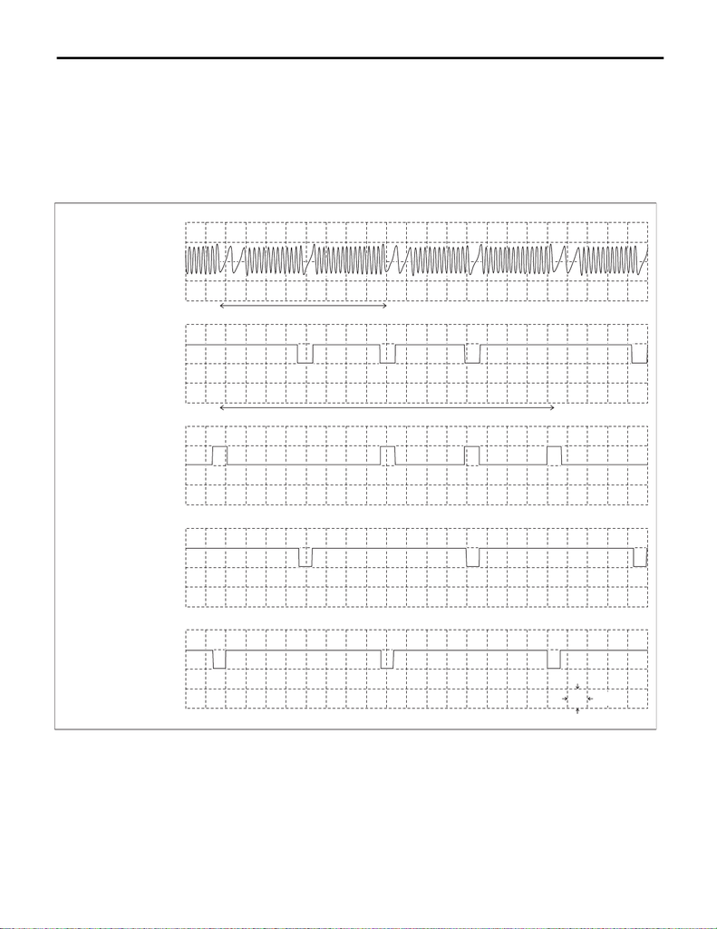

EN(STI)(diag)-24

Engine Control Module (ECM) I/O Signal

ENGINE (DIAGNOSTICS)

Input/output name:

• Crankshaft position sensor

• Intake camshaft position sensor RH

• Intake camshaft position sensor LH

• Exhaust camshaft position sensor RH

• Exhaust camshaft position sensor LH

Measuring condition:

• After warming-up

• At idling

5 V

10 ms

0

0

0

0

0

EN-07431

INTAKE CAMSHAFT

POSITION SENSOR LH

INTAKE CAMSHAFT

POSITION SENSOR RH

CRANKSHAFT

POSITION SENSOR

EXHAUST CAMSHAFT

POSITION SENSOR LH

EXHAUST CAMSHAFT

POSITION SENSOR RH

ONE CRANKSHAFT ROTATION

ONE CAMSHAFT ROTATION

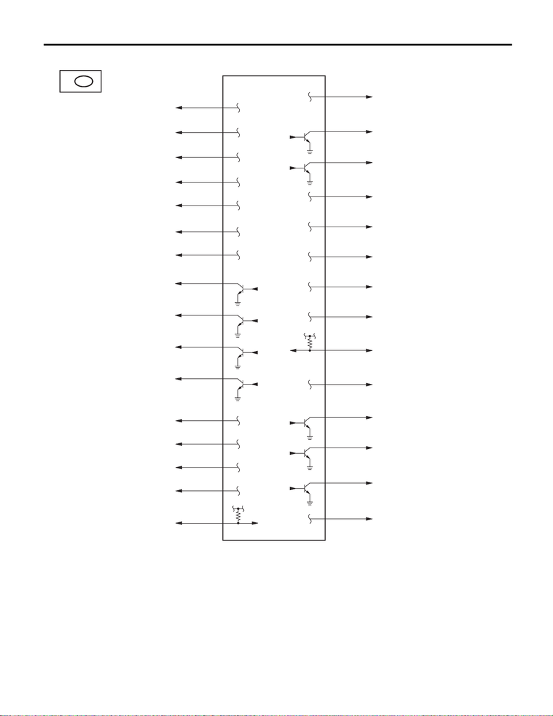

EN(STI)(diag)-25

Engine Control Module (ECM) I/O Signal

ENGINE (DIAGNOSTICS)

B134A:

A19

EN-10846

A6

A4

A3

A2

A1

A11

A10

A13

A12

A28

A29

A34

A21

A22

A31

A32

A18

A23

A33

A24

A25

A26

A17

A16

A27

A7

A5

A15

A14

EXHAUST OIL FLOW

CONTROL SOLENOID VALVE LH

EXHAUST OIL FLOW

CONTROL SOLENOID VALVE RH

EXHAUST OIL FLOW

CONTROL SOLENOID VALVE LH

EXHAUST OIL FLOW

CONTROL SOLENOID VALVE RH

INTAKE OIL FLOW

CONTROL SOLENOID VALVE RH

INTAKE OIL FLOW

CONTROL SOLENOID VALVE LH

INTAKE OIL FLOW

CONTROL SOLENOID VALVE LH

TUMBLE GENERATOR VALVE ASSY RH

TUMBLE GENERATOR VALVE ASSY RH

TUMBLE GENERATOR VALVE ASSY LH

WASTEGATE CONTROL SOLENOID VALVE

TUMBLE GENERATOR VALVE ASSY LH

ELECTRONIC THROTTLE CONTROL

IGNITION COIL No. 4

IGNITION COIL No. 3

IGNITION COIL No. 2

IGNITION COIL No. 1

INTAKE OIL FLOW

CONTROL SOLENOID VALVE RH

GROUNDS

ELECTRONIC THROTTLE CONTROL

FUEL INJECTOR No. 3

FUEL INJECTOR No. 4

FUEL INJECTOR No. 1

FUEL INJECTOR No. 2

ELECTRONIC THROTTLE CONTROL

ELECTRONIC THROTTLE CONTROL

ENGINE GROUND

ENGINE GROUND

ENGINE GROUND

POWER LINES

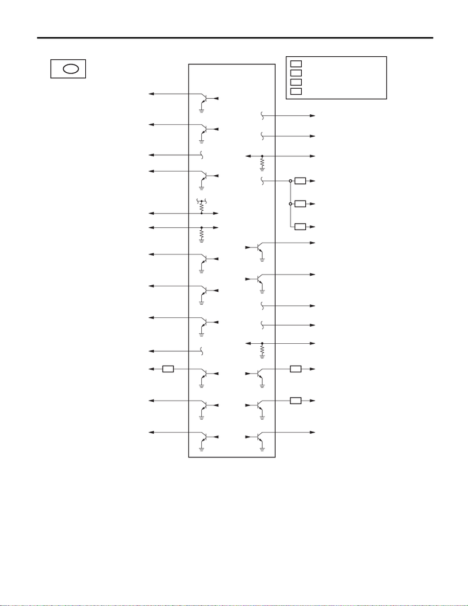

EN(STI)(diag)-26

Engine Control Module (ECM) I/O Signal

ENGINE (DIAGNOSTICS)

B32

WP

B34

WP

B15

WP

B6

EN-10847

B11

B13

B14

B7

B23

B31

B26

B10

B17

B22

B29

B30

B135B:

B12

B35

B4

B8

B27

B21

ID

B25

OP

ND

OP

ND

ID

WP

B9

B20

SECONDARY

AIR COMBINATION VALVE RELAY 2

CLUTCH SWITCH

: WITH PUSH BUTTON START

: WITH ID CODE BOX

: WITHOUT ID CODE BOX

: WITHOUT PUSH BUTTON START

BODY INTEGRATED UNIT

KEYLESS ACCESS CM

ID CODE BOX

ACCELERATOR PEDAL POSITION SENSOR

SECONDARY AIR PUMP RELAY

SECONDARY

AIR COMBINATION VALVE RELAY 1

LEAK CHECK VALVE ASSY

A/C RELAY

MAIN FAN RELAY

GROUNDS

ACCELERATOR PEDAL POSITION SENSOR

POWER LINES

ELECTRONIC THROTTLE CONTROL RELAY

FUEL PUMP CU

STARTER RELAY

ACCELERATOR PEDAL POSITION SENSOR

ACCELERATOR PEDAL POSITION SENSOR

ELECTRONIC THROTTLE CONTROL RELAY

DATA LINK CONNECTOR

RELAY CONTROLS

SUB FAN RELAY

REAR OXYGEN SENSOR

KEYLESS ACCESS CM

STARTER CUT RELAY

KEYLESS ACCESS CM

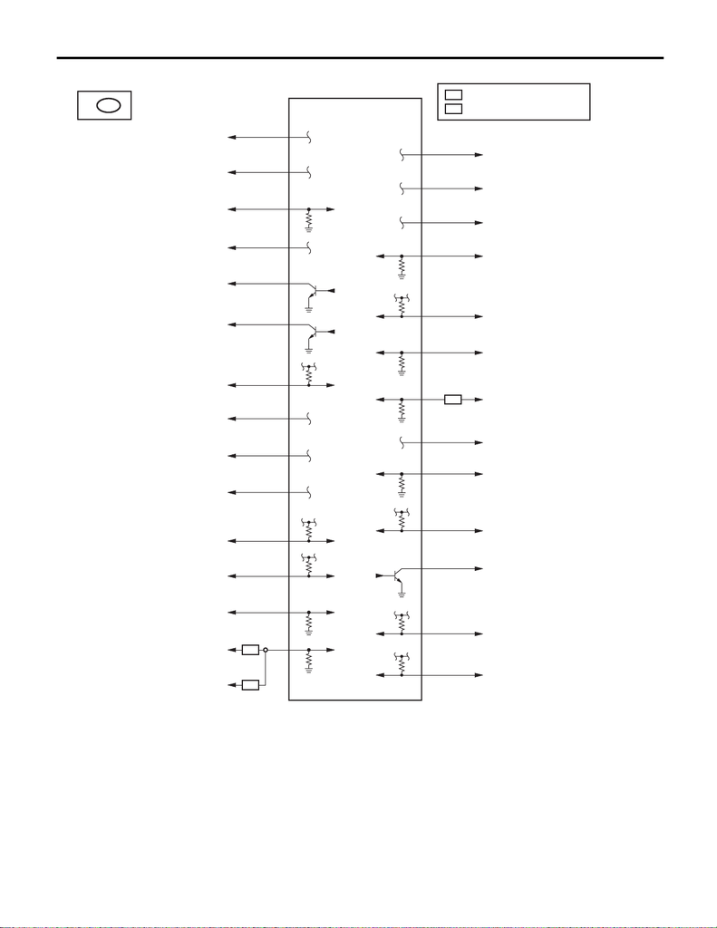

EN(STI)(diag)-27

Engine Control Module (ECM) I/O Signal

ENGINE (DIAGNOSTICS)

WP

C16

OP

EN-10848

C6

C5

C2

C22

C28

C3

C1

C4

C12

C7

C10

C9

C11

C13

C15

C21

C30

C31

C34

C35

C18

C19

C20

B136C:

C33

C17

OP

WP

C27

WP

STARTER RELAY

SEVERAL MODULES (CAN COMMUNICATION)

: WITH PUSH BUTTON START

: WITHOUT PUSH BUTTON START

FUEL PUMP CU

REAR OXYGEN SENSOR

FRONT OXYGEN (A/F) SENSOR

FRONT OXYGEN (A/F) SENSOR

NEUTRAL POSITION SWITCH

DELIVERY MODE FUSE

MASS AIR FLOW &

INTAKE AIR TEMPERATURE SENSOR

F/B FUSE No. 12

LEAK CHECK VALVE ASSY

BRAKE SWITCH

CRUISE CONTROL SWITCH

MASS AIR FLOW &

INTAKE AIR TEMPERATURE SENSOR

SHIELDS

MASS AIR FLOW &

INTAKE AIR TEMPERATURE SENSOR

(SHIELD)

PRESSURE SWITCH

CRUISE CONTROL SWITCH

GROUNDS

MAIN RELAY

STOP LIGHT SWITCH

SEVERAL MODULES (CAN COMMUNICATION)

MASS AIR FLOW &

INTAKE AIR TEMPERATURE SENSOR

M/B FUSE No. 13

FRONT OXYGEN (A/F) SENSOR

FRONT OXYGEN (A/F) SENSOR

STARTER RELAY

KEYLESS ACCESS CM

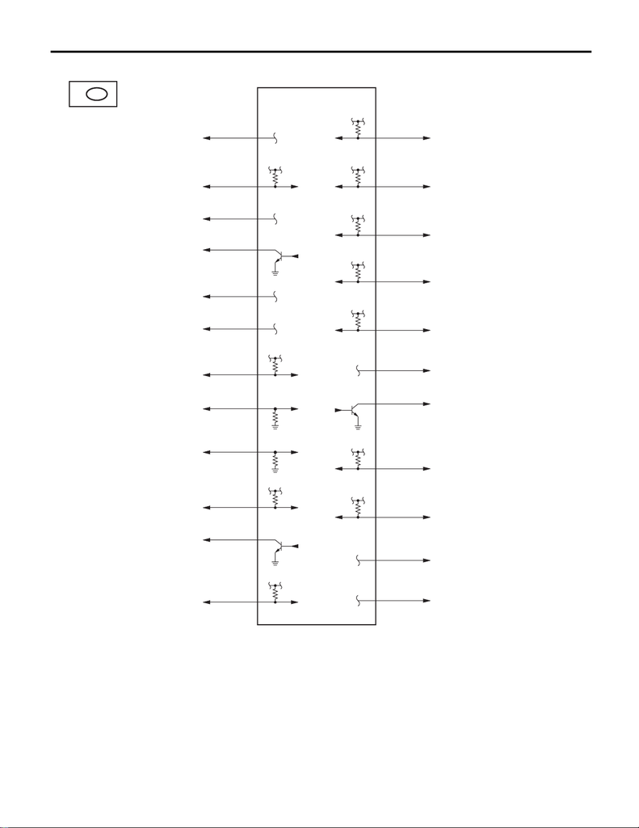

EN(STI)(diag)-28

Engine Control Module (ECM) I/O Signal

ENGINE (DIAGNOSTICS)

D10

EN-10849

D6

D7

D1

D3

D2

D8

D22

D25

D30

D28

D31

D24

B137D:

D20

D15

D11

D17

D27

D12

D9

D23

D29

D16

INTAKE CAMSHAFT POSITION SENSOR LH

EXHAUST CAMSHAFT POSITION SENSOR LH

EXHAUST CAMSHAFT POSITION SENSOR RH

SECONDARY AIR COMBINATION VALVE

(WITH BUILT-IN PRESSURE SENSOR)

PCV HOSE ASSY

LEAK CHECK VALVE ASSY

CRANKSHAFT POSITION SENSOR

TUMBLE GENERATOR VALVE ASSY RH

PURGE CONTROL SOLENOID VALVE 2

MANIFOLD ABSOLUTE PRESSURE SENSOR

INTAKE CAMSHAFT POSITION SENSOR RH

CRANKSHAFT POSITION SENSOR (SHIELD)

POWER STEERING OIL PRESSURE SWITCH

EACH CAMSHAFT POSITION SENSOR

(GROUND)

CRANKSHAFT POSITION SENSOR

ENGINE COOLANT TEMPERATURE SENSOR

KNOCK SENSOR (SHIELD)

KNOCK SENSOR

ENGINE GROUND

ENGINE GROUND

MAIN RELAY

PURGE CONTROL SOLENOID VALVE 1

TUMBLE GENERATOR VALVE ASSY LH